# Risk Analysis in the Strait of Hormuz: Wartime Insurance Premiums

Kalika Desai

2026-05-01

# Introduction

The Strait of Hormuz is an essential waterway between the Persian Gulf and the Gulf of Oman, bordered by Iran [1]. Currently, 20% of the world’s liquefied natural gas and 25% of seaborne oil trade passes through the strait annually [1]. Changes to safety or blocked transit through the strait can cause supply delays and increase shipping costs. Recently, the 2026 Strait of Hormuz crisis has restricted shipments by more than 90% [1]. As a result, insurance rates for oil tankers have surged due to the extreme risk of an Iranian attack. For this project, I will use Monte Carlo to simulate voyages through the Strait of Hormuz in order to estimate an insurance premium during wartime.

In general, maritime cargo insurance is split into hull & machinery, cargo, protection & indemnity, and war risk premiums. Hull and machinery insurance is based on the ship’s value, which I have ranged from about $100 million to $150 million [2]. The cargo insurance is based on the number of barrels the ship can hold–1.9 million to 2.2 million–and the current crude oil price per barrel–$85 to $113-during the 2026 conflict [3] [4]. Protection and indemnity insurance is related to costs of medical care for injured crew and potential costs for oil spill cleanup. These costs can vary greatly depending on the severity of the attack. Oil spill cleanup costs are also very variable. Rough estimates ranging from $6 million to $600 million are given based on severity of the spill [5]. While estimates are calculated for these premiums in order to produce a total insurance estimate, I am most interested in the Additional War Risk Premium. An AWRP is an added cost that is applied to ships going through particularly volatile routes, such as the Strait of Hormuz during March and April 2026 [6]. When war risk is high and an attack is possible, the AWRP is often the majority of the cost to insure an oil tanker.

# Demonstration

## Defining Parameters

First, a function is created to sample parameters to be used later. As previously mentioned, ship value, cargo capacity, and crude oil price per barrel can vary, so they are sampled randomly from Uniform distributions. Scaling parameters for the hit probability function are set, as well as the probability of an attack and an average freight value. Additionally, there is a function that builds a trajectory data frame which holds all x and y points along the path.

```r
library(sf)
library(rnaturalearth)
library(ggplot2)
library(scales)
```

```r
sample_parameters <- function() {
  ship_value <- runif(1, 100e6, 150e6)
  barrels <- runif(1, 1.9e6, 2.2e6)
  oil_price <- runif(1, 85, 113)

  list(
    lambda = 0.2,
    temp = 0.5,
    ship_value = ship_value,
    cargo_value = barrels * oil_price,
    attack_prob = 0.05,
    freight = 5e6
  )
}

build_trajectory <- function(path, ng = 10) {
  x_traj <- c(seq(path[1,1], path[2,1], length.out=ng),
              seq(path[2,1], path[3,1], length.out=ng)[2:ng])
  y_traj <- c(seq(path[1,2], path[2,2], length.out=ng),
              seq(path[2,2], path[3,2], length.out=ng)[2:ng])
  traj_df <- data.frame(x=x_traj,y=y_traj)
  return(traj_df)
}
```

## Hit Probability Function and Losses

Next, the probability function for a given launch site is defined by:
$$p_i=\lambda e^{-d_i/T}$$

The $\lambda$ and T (temp) values are hard-coded in the parameters. The $d_i$ is a distance from the current position of the ship to a particular launch site. As the ship gets farther away from the launch site, the probability of a hit decreases. The probability of at least one hit from any of the launch sites at a given position is given by:
$$1-\prod(1-p_i)$$

If the ship is attacked and hit at any point in the voyage, the losses are calculated. First, severity of the attack is sampled at random given the probability of each occurring. Minor damage is most likely to happen, while catastrophic damage is the least likely. Given the severity, the amount of damage is randomly sampled and used to calculate the monetary loss/cost for hull, cargo, spill, and crew.

```r
compute_hit_prob <- function(traj_df, launch_sites, params, t) {
  current_pos <- traj_df[t,]
  all_points <- rbind(current_pos,launch_sites)
  dists <- as.matrix(dist(all_points))[1,2:(nrow(launch_sites)+1)]

  prob_site <- params$lambda * exp(-dists / params$temp)
  hit_prob <- 1 - prod(1 - prob_site)
  return(hit_prob)
}

simulate_loss <- function(params) {
  severity <- sample(c("minor", "moderate", "catastrophic"), size = 1,
                     prob = c(0.6, 0.3, 0.1))

  if (severity == "minor") {
    hull <- runif(1, 0.05, 0.2) * params$ship_value
    cargo <- runif(1, 0.05, 0.2) * params$cargo_value
    spill <- rgamma(1, 2, scale = 3e6)
  }

  if (severity == "moderate") {
    hull  <- runif(1, 0.2, 0.6) * params$ship_value
    cargo <- runif(1, 0.2, 0.6) * params$cargo_value
    spill <- rgamma(1, 2, scale = 15e6)
  }

  if (severity == "catastrophic") {
    hull  <- params$ship_value
    cargo <- params$cargo_value
    spill <- rgamma(1, 2, scale = 300e6)
  }

  crew <- rlnorm(1, log(1e6), 0.5)

  list(
    hull = hull,
    cargo = cargo,
    spill = spill,
    crew = crew,
    total = hull + cargo + spill + crew
  )
}
```

## Simulate a Voyage

Given a trajectory through the strait and launch sites, a voyage is simulated. At each step along the path, the probability of an attack is used to determine if an attack occurs or not. If the ship is attacked, the probability of a hit is calculated from the previously defined function. If the ship is hit, the losses are calculated from the previously defined function. The ship will continue along the voyage until it is attacked and hit. If no hit occurs, all losses returned are 0.

```r
simulate_voyage <- function(traj_df, launch_sites, params) {
  tsteps <- nrow(traj_df)

  for (t in 1:tsteps) {
    attack <- runif(1) < params$attack_prob
    hit_prob <- compute_hit_prob(traj_df, launch_sites, params, t)

    if (attack) {
      if (runif(1) < hit_prob) {
        loss <- simulate_loss(params)
        loss$hit <- 1
        loss$hit_prob <- hit_prob
        return(loss)
      }
    }
  }
  return(list(
    hull = 0,
    cargo = 0,
    spill = 0,
    crew = 0,
    total = 0,
    hit = 0,
    hit_prob = hit_prob
  ))
}
```

## Calculate Insurance Premiums

Given the losses and ship parameters from a single voyage, the estimated insurance premiums are calculated. In general, a simple equation is given to calculate a maritime insurance premium [7]:
$$\text{Premium}
= \text{Insured Value} \times \text{Insurance Rate}$$

General insurance rates are hard-coded and applied to each category of premium. The war-related premium is dependent on hit probability in order to capture the stochastic risk during wartime.

```r
calculate_premiums <- function(losses, params) {
  insured_cargo <- (params$cargo_value + params$freight) * 1.10

  hm_rate <- 0.01
  cargo_rate <- 0.005
  awrp_rate <- 0.03

  premium_hm <- params$ship_value * hm_rate
  premium_cargo <- insured_cargo * cargo_rate
  premium_war <- (params$ship_value + params$cargo_value) * awrp_rate *
    (1 + 5 * losses$hit_prob)
  premium_pi <- (losses$spill + losses$crew) * 1.2

  total_premium <- premium_hm + premium_cargo + premium_war + premium_pi

  list(
    total_premium = total_premium,
    premium_war = premium_war)
}
```

## Monte Carlo Simulation

Finally, I simulate 1,000 voyages through the Strait of Hormuz. For each voyage, new parameters are sampled to represent various ships with different hull and cargo values, as well as fluctuating crude oil prices. This represents the variability in type of oil tanker travelling through the strait at a given time. In addition, the losses are calculated per voyage to capture the range in minor, moderate, and catastrophic events. Premium costs are calculated per voyage as well, to incorporate that voyages predicted losses. The results section will reveal key expected values and predicted risk.

```r
set.seed(123)
path <- data.frame(x=c(54.6,56.5,57),
                   y=c(25.5,26.5,24.25))

launch_sites <- data.frame(x=c(55.9,56.8,56),
                           y=c(26.75,27.2,27.5))

traj_df <- build_trajectory(path)

nsim <- 1000
premiums <- vector("list", nsim)
hits <- numeric(nsim)
total_loss <- numeric(nsim)

for (i in 1:nsim) {
  params <- sample_parameters()
  losses <- simulate_voyage(traj_df, launch_sites, params)
  hits[i] <- losses$hit
  total_loss[i] <- losses$total
  premiums[[i]] <- calculate_premiums(losses, params)
}
```

# Key Results

The expected total premium for a ship traveling through the Strait of Hormuz during wartime is approximately $17 million. Of that total, the expected war premium is approximately $10 million. This means abut 58% of the insurance premium is coming from the AWRP. This is at an AWRP rate of 0.03, which is common for aggravated war risk [8]. The expected total loss from a voyage is about $7.8 million, but this is very variable depending on the severity of the attack. Additionally, the model estimates a 2.9% probability of a successful attack per voyage under the assumed attack frequency. For simplicity, I set a 0.05 attack probability to be equal at each point along the route. This implies multiple attack opportunities along the route. This reflects a worst-case scenario in a high-risk wartime situation. In reality, a 3% probability of a hit is very risky, which is why the total premium is so large.

```r
prem_df <- do.call(rbind, lapply(premiums, as.data.frame))
summary_table <- data.frame(
  Metric = c("Expected Total Premium",
             "Expected War Premium",
             "Expected Total Loss",
             "Hit Probability"),
  Value = c(mean(prem_df$total_premium),
            mean(prem_df$premium_war),
            mean(total_loss),
            mean(hits))
)

summary_table
```

```
##                   Metric        Value
## 1 Expected Total Premium 17193335.090
## 2   Expected War Premium 10062267.516
## 3    Expected Total Loss  7763263.689
## 4        Hit Probability        0.029
```

The below histogram represents the distribution of losses during wartime. The majority of losses are less than $500 million, which represent lower possible premiums. However, the possibility of rare catastrophic attacks skew the distribution heavily to the right. This is seen with only three instances of war losses greater than $1 billion. These rare cases that skew the loss distribution raise the cost of premiums in order to cover the possibility of them occurring.

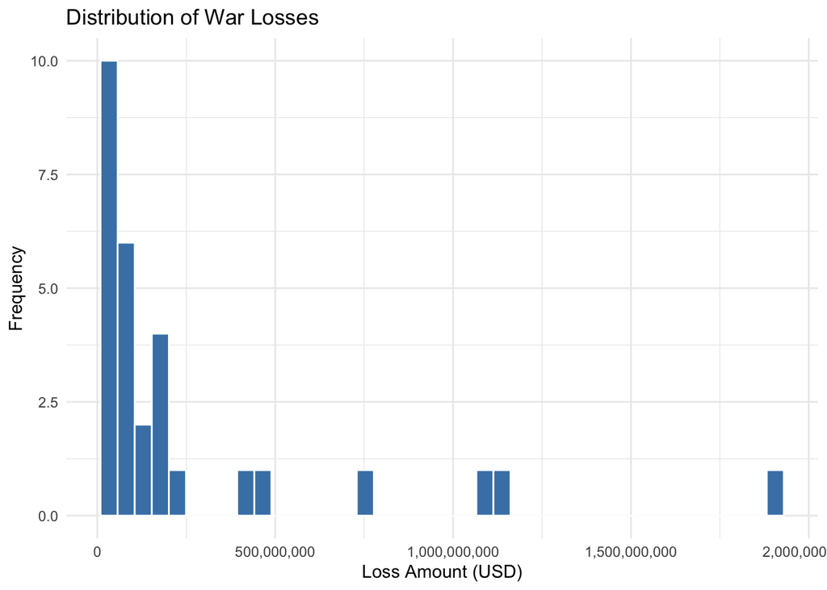

```r
non_zero_loss <- total_loss[total_loss > 0]
ggplot(data.frame(loss = non_zero_loss), aes(x = loss)) +
  geom_histogram(bins = 40, fill = "steelblue", color = "white") +
  scale_x_continuous(labels = comma) +
  theme_minimal() +
  labs(title = "Distribution of War Losses",
       x = "Loss Amount (USD)",
       y = "Frequency")
```

The distribution of war premiums is mainly centered around the expected value of $10 million. There is a right tail that is skewing the distribution towards extreme premiums of up to $17.5 million. As war premium is dependent on the hit probability, this shows the volatile nature of war risk. Voyages with a high probability of being hit raise the premium to an extreme amount. This model predicts the worst-case scenario, so likely insurance would be cancelled altogether before actually reaching these extreme amounts in the tail.

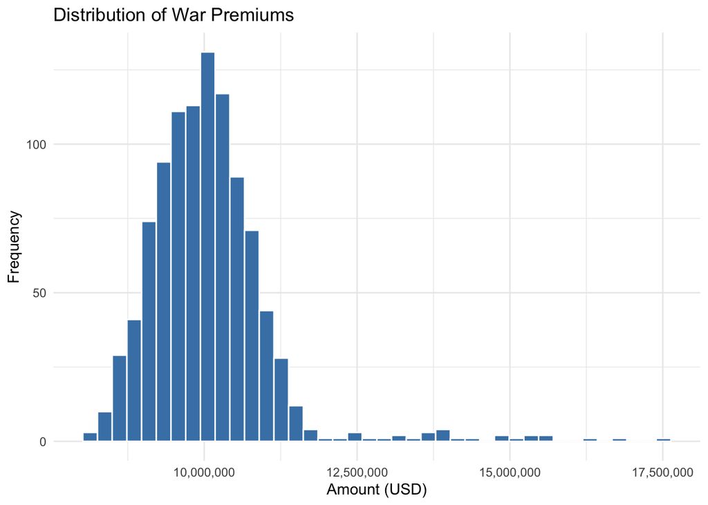

```r
ggplot(prem_df, aes(x = premium_war)) +
  geom_histogram(bins = 40, fill = "steelblue", color = "white") +
  scale_x_continuous(labels = comma) +
  theme_minimal() +
  labs(title = "Distribution of War Premiums",
       x = "Amount (USD)",
       y = "Frequency")
```

The world plot below represents a possible route through the Strait of Hormuz, 19 evenly spaced steps, and three launch sites in Iran. Each of the points along the route are colored by hit probability. As the ship gets closer to the launch sites, the probability of being hit increases. Conversely, the further away from the launch sites the ship is, the lower the probability of being hit.

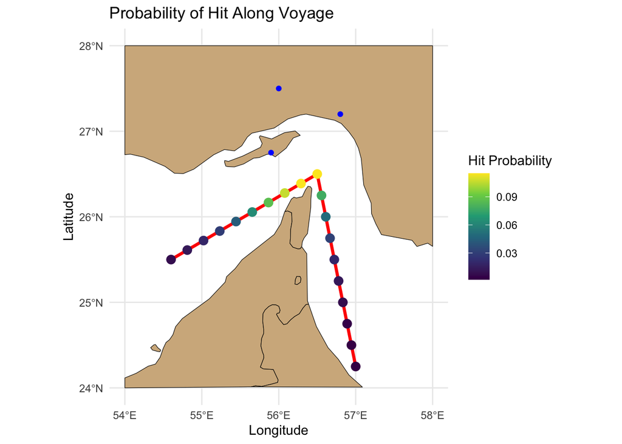

```r
# world map
world <- ne_countries(scale = "medium", returnclass = "sf")

# bounding box around Persian Gulf
pg_bbox <- st_bbox(c(
  xmin = 54,
  xmax = 58,
  ymin = 24,
  ymax = 28
), crs = st_crs(world))

pg <- st_crop(world, pg_bbox)
hit_probs <- sapply(1:nrow(traj_df), function(t) {
  compute_hit_prob(traj_df, launch_sites, params, t)
})
traj_df$hit_prob <- hit_probs

ggplot(pg) +
  geom_sf(fill = "tan", color = "black") +
  geom_line(data = path, aes(x = x, y = y),
            color = "red", linewidth = 1.2) +
  geom_point(data = launch_sites, aes(x=x,y=y), color = 'blue') +
  geom_point(data = traj_df, aes(x=x,y=y, color = hit_prob), size = 3) +
  scale_color_viridis_c(name = "Hit Probability") +
  labs(
    title = "Probability of Hit Along Voyage",
    x = "Longitude",
    y = "Latitude"
  ) +
  theme_minimal()
```

A similar pattern is shown below in the relationship between time step in the simulation and hit probability. The maximum hit probability is near the middle of the voyage where the ship is the smallest distance from the launch sites.

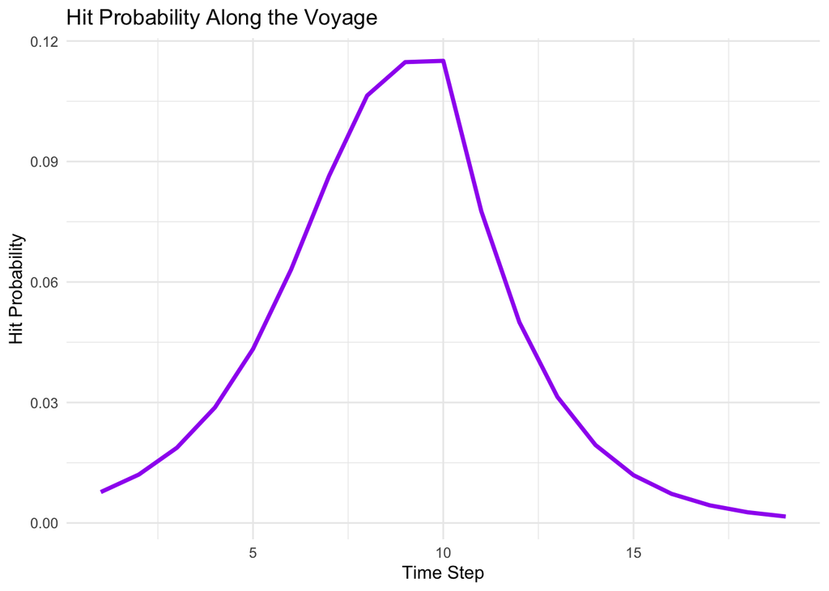

```r
ggplot(data.frame(step = 1:length(hit_probs), hp = hit_probs),
       aes(x = step, y = hp)) +
  geom_line(color = "purple", linewidth = 1.2) +
  theme_minimal() +
  labs(title = "Hit Probability Along the Voyage",
       x = "Time Step",
       y = "Hit Probability")
```

# Conclusion

The model I use to determine insurance premiums during wartime is conservative, revealing the worst-case scenario of attacks within the strait. Due to this, the probability of being hit during a voyage is about 3%, given multiple independent chances of attack. As a result, the projected insurance premium is large, indicating the high risk of a ship traveling during wartime. The Additional War Risk Premium is the majority of the cost of total insurance due to its dependence on war risk. During a high risk voyage, such as through the Strait of Hormuz during the current crisis, the risk of attack is great, exposing the necessity of surging insurance rates.

The Monte Carlo method of repeated random sampling has allowed me to obtain a numerical estimation for insurance premiums. By randomly sampling ship attributes, this allowed for a realistic representation of many different kinds of ships traveling and needing insurance. Over 1,000 voyages, I was able to approximate the insurance required to cover expected losses, which was dependent on the risk and probability of being hit.

Given the complexity of maritime insurance, my model is a simple version of a possible actuarial risk analysis. The amount of loss experienced from an attack is extremely variable, especially in terms of oil spills, so for simplicity I gave general estimates for costs. In addition, the weapons used at each launch site could differ. With newer technology, drones have very good accuracy and are often deployed in war. The hit probability I used is a simple distance decay function, which may not represent the nuanced complexity in military weapons.

# References

[1]

“Strait of Hormuz,” *Wikipedia*. May 2026. Accessed: May 03, 2026. [Online]. Available: https://en.wikipedia.org/w/index.php?title=Strait_of_Hormuz&oldid=1352383628

[2]

“VLCC second-hand prices at decade highs,” *Breakwave Advisors*. Mar. 2026. Accessed: May 03, 2026. [Online]. Available: https://www.breakwaveadvisors.com/insights/2026/3/2/vlcc-second-hand-prices-at-decade-highs

[3]

“Oil tanker sizes range from general purpose to ultra-large crude carriers on AFRA scale - U.S. Energy Information Administration (EIA).” Accessed: May 03, 2026. [Online]. Available: https://www.eia.gov/todayinenergy/detail.php?id=17991

[4]

“Crude Oil - Price - Chart - Historical Data - News.” Accessed: May 03, 2026. [Online]. Available: https://tradingeconomics.com/commodity/crude-oil

[5]

K. Greenstreet, “Oil Spill Economics Revealed: The True Financial Burden of Oil and Water Spills and How to Reduce Costs,” *VisionAery*. Jan. 2024. Accessed: May 04, 2026. [Online]. Available: https://www.visionaery.com/post/staggering-oil-spill-economics-revealed-the-true-financial-burden-of-oil-and-water-spills-and-how-t

[6]

J. Ollett, “Explainer: War risk insurance and AWRP Latest Market News.” Mar. 2026. Accessed: May 03, 2026. [Online]. Available: https://www.argusmedia.com/en/news-and-insights/latest-market-news/2795769-explainer-war-risk-insurance-and-awrp

[7]

D. Singh, “The Hidden Cost in Your Shipments: How to Calculate Marine Insurance Accurately.” Mar. 2026. Accessed: May 03, 2026. [Online]. Available: https://intoglo.com/blog/the-hidden-cost-in-your-shipments-how-to-calculate-marine-insurance-accurately

[8]

N. Hussain and M. Saini, “Maritime insurance premiums surge as Iran conflict widens,” *Reuters*. Mar. 2026. Available: https://www.reuters.com/world/middle-east/maritime-insurance-premiums-surge-iran-conflict-widens-2026-03-06/